# Elsevier 2022 SDG mapping

)

)

OR

(

(

(TITLE-ABS("participation of Lesotho") OR TITLE-ABS("participation of Liberia") OR TITLE-ABS("participation of Libya") OR TITLE-ABS("participation of Macedonia") OR TITLE-ABS("participation of Madagascar") OR TITLE-ABS("participation of Malawi") OR TITLE-ABS("participation of Malaysia") OR TITLE-ABS("participation of Maldives") OR TITLE-ABS("participation of Mali") OR TITLE-ABS("participation of Marshall Islands") OR TITLE-ABS("participation of Mauritania") OR TITLE-ABS("participation of Mauritius") OR TITLE-ABS("participation of Mexico") OR TITLE-ABS("participation of Mongolia") OR TITLE-ABS("participation of Montenegro") OR TITLE-ABS("participation of Morocco") OR TITLE-ABS("participation of Mozambique") OR TITLE-ABS("participation of Myanmar") OR TITLE-ABS("participation of Namibia") OR TITLE-ABS("participation of Nauru") OR TITLE-ABS("participation of Nepal") OR TITLE-ABS("participation of Nicaragua") OR TITLE-ABS("participation of Niger") OR TITLE-ABS("participation of Nigeria") OR TITLE-ABS("participation of Niue") OR TITLE-ABS("participation of Pakistan") OR TITLE-ABS("participation of Palau") OR TITLE-ABS("participation of Palestine") OR TITLE-ABS("participation of Panama") OR TITLE-ABS("participation of Papua New Guinea") OR TITLE-ABS("participation of Paraguay") OR TITLE-ABS("participation of Peru") OR TITLE-ABS("participation of Philippines") OR TITLE-ABS("participation of Moldova") OR TITLE-ABS("participation of Rwanda") OR TITLE-ABS("participation of Saint Vincent and the Grenadines") OR TITLE-ABS("participation of Samoa") OR TITLE-ABS("participation of São Tomé and Príncipe") OR TITLE-ABS("participation of Senegal") OR TITLE-ABS("participation of Serbia") OR TITLE-ABS("participation of Sierra Leone") OR TITLE-ABS("participation of Solomon Islands") OR TITLE-ABS("participation of Somalia") OR TITLE-ABS("participation of South Africa") OR TITLE-ABS("participation of South Sudan") OR TITLE-ABS("participation of Sri Lanka") OR TITLE-ABS("participation of Saint Lucia") OR TITLE-ABS("participation of Sudan") OR TITLE-ABS("participation of Suriname") OR TITLE-ABS("participation of Syria") OR TITLE-ABS("participation of Tajikistan") OR TITLE-ABS("participation of Thailand") OR TITLE-ABS("participation of Timor-Leste") OR TITLE-ABS("participation of Togo") OR TITLE-ABS("participation of Tonga") OR TITLE-ABS("participation of Tunisia") OR TITLE-ABS("participation of Turkey") OR TITLE-ABS("participation of Turkmenistan") OR TITLE-ABS("participation of Tuvalu") OR TITLE-ABS("participation of Uganda") OR TITLE-ABS("participation of Ukraine") OR TITLE-ABS("participation of Tanzania") OR TITLE-ABS("participation of Uzbekistan") OR TITLE-ABS("participation of Vanuatu") OR TITLE-ABS("participation of Venezuela") OR TITLE-ABS("participation of Viet Nam") OR TITLE-ABS("participation of Yemen") OR TITLE-ABS("participation of Zambia") OR TITLE-ABS("participation of Zimbabwe")) AND (TITLE-ABS("global institution") OR TITLE-ABS("global institutions") OR TITLE-ABS("international institution") OR TITLE-ABS("international institutions") OR TITLE-ABS("global financial institution") OR TITLE-ABS("global financial institutions") OR TITLE-ABS("international financial institution") OR TITLE-ABS("international financial institutions") OR TITLE-ABS("global economic institution") OR TITLE-ABS("global economic institutions") OR TITLE-ABS("international economic institution") OR TITLE-ABS("international economic institutions") OR TITLE-ABS("global environmental institution") OR TITLE-ABS("global environmental institutions") OR TITLE-ABS("international environmental institution") OR TITLE-ABS("international environmental institutions") OR TITLE-ABS("global energy institution") OR TITLE-ABS("global energy institutions") OR TITLE-ABS("international energy institution") OR TITLE-ABS("international energy institutions") OR TITLE-ABS("global climate institution") OR TITLE-ABS("global climate institutions") OR TITLE-ABS("international climate institution") OR TITLE-ABS("international climate institutions") OR TITLE-ABS("global governance") OR TITLE-ABS("international governance") OR TITLE-ABS("global financial governance") OR TITLE-ABS("international financial governance") OR TITLE-ABS("global economic governance") OR TITLE-ABS("international economic governance") OR TITLE-ABS("global environmental governance") OR TITLE-ABS("international environmental governance") OR TITLE-ABS("global energy governance") OR TITLE-ABS("international energy governance") OR TITLE-ABS("global climate governance") OR TITLE-ABS("international climate governance") OR TITLE-ABS("United Nations") OR TITLE-ABS("International Atomic Energy Agency") OR TITLE-ABS("International Civil Aviation Organization") OR TITLE-ABS("International Fund for Agricultural Development") OR TITLE-ABS("International Labour Organization") OR TITLE-ABS("International Maritime Organization") OR TITLE-ABS("International Monetary Fund") OR TITLE-ABS("International Telecommunication Union") OR TITLE-ABS("Universal Postal Union") OR TITLE-ABS("World Bank") OR TITLE-ABS("World Intellectual Property Organization") OR TITLE-ABS("World Meteorological Organization") OR TITLE-ABS("World Health Organization") OR TITLE-ABS("World Trade Organization") OR TITLE-ABS("Bretton Woods Institutions") OR TITLE-ABS("Organisation for Economic Cooperation and Development"))

)

OR

(

(TITLE-ABS("participation of Lesotho") OR TITLE-ABS("participation of Liberia") OR TITLE-ABS("participation of Libya") OR TITLE-ABS("participation of Macedonia") OR TITLE-ABS("participation of Madagascar") OR TITLE-ABS("participation of Malawi") OR TITLE-ABS("participation of Malaysia") OR TITLE-ABS("participation of Maldives") OR TITLE-ABS("participation of Mali") OR TITLE-ABS("participation of Marshall Islands") OR TITLE-ABS("participation of Mauritania") OR TITLE-ABS("participation of Mauritius") OR TITLE-ABS("participation of Mexico") OR TITLE-ABS("participation of Mongolia") OR TITLE-ABS("participation of Montenegro") OR TITLE-ABS("participation of Morocco") OR TITLE-ABS("participation of Mozambique") OR TITLE-ABS("participation of Myanmar") OR TITLE-ABS("participation of Namibia") OR TITLE-ABS("participation of Nauru") OR TITLE-ABS("participation of Nepal") OR TITLE-ABS("participation of Nicaragua") OR TITLE-ABS("participation of Niger") OR TITLE-ABS("participation of Nigeria") OR TITLE-ABS("participation of Niue") OR TITLE-ABS("participation of Pakistan") OR TITLE-ABS("participation of Palau") OR TITLE-ABS("participation of Palestine") OR TITLE-ABS("participation of Panama") OR TITLE-ABS("participation of Papua New Guinea") OR TITLE-ABS("participation of Paraguay") OR TITLE-ABS("participation of Peru") OR TITLE-ABS("participation of Philippines") OR TITLE-ABS("participation of Moldova") OR TITLE-ABS("participation of Rwanda") OR TITLE-ABS("participation of Saint Vincent and the Grenadines") OR TITLE-ABS("participation of Samoa") OR TITLE-ABS("participation of São Tomé and Príncipe") OR TITLE-ABS("participation of Senegal") OR TITLE-ABS("participation of Serbia") OR TITLE-ABS("participation of Sierra Leone") OR TITLE-ABS("participation of Solomon Islands") OR TITLE-ABS("participation of Somalia") OR TITLE-ABS("participation of South Africa") OR TITLE-ABS("participation of South Sudan") OR TITLE-ABS("participation of Sri Lanka") OR TITLE-ABS("participation of Saint Lucia") OR TITLE-ABS("participation of Sudan") OR TITLE-ABS("participation of Suriname") OR TITLE-ABS("participation of Syria") OR TITLE-ABS("participation of Tajikistan") OR TITLE-ABS("participation of Thailand") OR TITLE-ABS("participation of TimorLeste") OR TITLE-ABS("participation of Togo") OR TITLE-ABS("participation of Tonga") OR TITLE-ABS("participation of Tunisia") OR TITLE-ABS("participation of Turkey") OR TITLE-ABS("participation of Turkmenistan") OR TITLE-ABS("participation of Tuvalu") OR TITLE-ABS("participation of Uganda") OR TITLE-ABS("participation of Ukraine") OR TITLE-ABS("participation of Tanzania") OR TITLE-ABS("participation of Uzbekistan") OR TITLE-ABS("participation of Vanuatu") OR TITLE-ABS("participation of Venezuela") OR TITLE-ABS("participation of Viet Nam") OR TITLE-ABS("participation of Yemen") OR TITLE-ABS("participation of Zambia") OR TITLE-ABS("participation of Zimbabwe")) AND (TITLE-ABS("global institution") OR TITLE-ABS("global institutions") OR TITLE-ABS("international institution") OR TITLE-ABS("international institutions") OR TITLE-ABS("global financial institution") OR TITLE-ABS("global financial institutions") OR TITLE-ABS("international financial institution") OR TITLE-ABS("international financial institutions") OR TITLE-ABS("global economic institution") OR TITLE-ABS("global economic institutions") OR TITLE-ABS("international economic institution") OR TITLE-ABS("international economic institutions") OR TITLE-ABS("global environmental institution") OR TITLE-ABS("global environmental institutions") OR TITLE-ABS("international environmental institution") OR TITLE-ABS("international environmental institutions") OR TITLE-ABS("global energy institution") OR TITLE-ABS("global energy institutions") OR TITLE-ABS("international energy institution") OR TITLE-ABS("international energy institutions") OR TITLE-ABS("global climate institution") OR TITLE-ABS("global climate institutions") OR TITLE-ABS("international climate institution") OR TITLE-ABS("international climate institutions") OR TITLE-ABS("global governance") OR TITLE-ABS("international governance") OR TITLE-ABS("global financial governance") OR TITLE-ABS("international financial governance") OR TITLE-ABS("global economic governance") OR TITLE-ABS("international economic governance") OR TITLE-ABS("global environmental governance") OR TITLE-ABS("international environmental governance") OR TITLE-ABS("global energy governance") OR TITLE-ABS("international energy governance") OR TITLE-ABS("global climate governance") OR TITLE-ABS("international climate governance") OR TITLE-ABS("United Nations") OR TITLE-ABS("International Atomic Energy Agency") OR TITLE-ABS("International Civil Aviation Organization") OR TITLE-ABS("International Fund for Agricultural Development") OR TITLE-ABS("International Labour Organization") OR TITLE-ABS("International Maritime Organization") OR TITLE-ABS("International Monetary Fund") OR TITLE-ABS("International Telecommunication Union") OR TITLE-ABS("Universal Postal Union") OR TITLE-ABS("World Bank") OR TITLE-ABS("World Intellectual Property Organization") OR TITLE-ABS("World Meteorological Organization") OR TITLE-ABS("World Health Organization") OR TITLE-ABS("World Trade Organization") OR TITLE-ABS("Bretton Woods Institutions") OR TITLE-ABS("Organisation for Economic Cooperation and Development"))

)

)

OR

(

(

(AUTHKEY("participation of Lesotho") OR AUTHKEY("participation of Liberia") OR AUTHKEY("participation of Libya") OR AUTHKEY("participation of Macedonia") OR AUTHKEY("participation of Madagascar") OR AUTHKEY("participation of Malawi") OR AUTHKEY("participation of Malaysia") OR AUTHKEY("participation of Maldives") OR AUTHKEY("participation of Mali") OR AUTHKEY("participation of Marshall Islands") OR AUTHKEY("participation of Mauritania") OR AUTHKEY("participation of Mauritius") OR AUTHKEY("participation of Mexico") OR AUTHKEY("participation of Mongolia") OR AUTHKEY("participation of Montenegro") OR AUTHKEY("participation of Morocco") OR AUTHKEY("participation of Mozambique") OR AUTHKEY("participation of Myanmar") OR AUTHKEY("participation of Namibia") OR AUTHKEY("participation of Nauru") OR AUTHKEY("participation of Nepal") OR AUTHKEY("participation of Nicaragua") OR AUTHKEY("participation of Niger") OR AUTHKEY("participation of Nigeria") OR AUTHKEY("participation of Niue") OR AUTHKEY("participation of Pakistan") OR AUTHKEY("participation of Palau") OR AUTHKEY("participation of Palestine") OR AUTHKEY("participation of Panama") OR AUTHKEY("participation of Papua New Guinea") OR AUTHKEY("participation of Paraguay") OR AUTHKEY("participation of Peru") OR AUTHKEY("participation of Philippines") OR AUTHKEY("participation of Moldova") OR AUTHKEY("participation of Rwanda") OR AUTHKEY("participation of Saint Vincent and the Grenadines") OR AUTHKEY("participation of Samoa") OR AUTHKEY("participation of São Tomé and Príncipe") OR AUTHKEY("participation of Senegal") OR AUTHKEY("participation of Serbia") OR AUTHKEY("participation of Sierra Leone") OR AUTHKEY("participation of Solomon Islands") OR AUTHKEY("participation of Somalia") OR AUTHKEY("participation of South Africa") OR AUTHKEY("participation of South Sudan") OR AUTHKEY("participation of Sri Lanka") OR AUTHKEY("participation of Saint Lucia") OR AUTHKEY("participation of Sudan") OR AUTHKEY("participation of Suriname") OR AUTHKEY("participation of Syria") OR AUTHKEY("participation of Tajikistan") OR AUTHKEY("participation of Thailand") OR AUTHKEY("participation of Timor-Leste") OR AUTHKEY("participation of Togo") OR AUTHKEY("participation of Tonga") OR AUTHKEY("participation of Tunisia") OR AUTHKEY("participation of Turkey") OR AUTHKEY("participation of Turkmenistan") OR AUTHKEY("participation of Tuvalu") OR AUTHKEY("participation of Uganda") OR AUTHKEY("participation of Ukraine") OR AUTHKEY("participation of Tanzania") OR AUTHKEY("participation of Uzbekistan") OR AUTHKEY("participation of Vanuatu") OR AUTHKEY("participation of Venezuela") OR AUTHKEY("participation of Viet Nam") OR AUTHKEY("participation of Yemen") OR AUTHKEY("participation of Zambia") OR AUTHKEY("participation of Zimbabwe")) AND (AUTHKEY("global institution") OR AUTHKEY("global institutions") OR AUTHKEY("international institution") OR AUTHKEY("international institutions") OR AUTHKEY("global financial institution") OR AUTHKEY("global financial institutions") OR AUTHKEY("international financial institution") OR AUTHKEY("international financial institutions") OR AUTHKEY("global economic institution") OR AUTHKEY("global economic institutions") OR AUTHKEY("international economic institution") OR AUTHKEY("international economic institutions") OR AUTHKEY("global environmental institution") OR AUTHKEY("global environmental institutions") OR AUTHKEY("international environmental institution") OR AUTHKEY("international environmental institutions") OR AUTHKEY("global energy institution") OR AUTHKEY("global energy institutions") OR AUTHKEY("international energy institution") OR AUTHKEY("international energy institutions") OR AUTHKEY("global climate institution") OR AUTHKEY("global climate institutions") OR AUTHKEY("international climate institution") OR AUTHKEY("international climate institutions") OR AUTHKEY("global governance") OR AUTHKEY("international governance") OR AUTHKEY("global financial governance") OR AUTHKEY("international financial governance") OR AUTHKEY("global economic governance") OR AUTHKEY("international economic governance") OR AUTHKEY("global environmental governance") OR AUTHKEY("international environmental governance") OR AUTHKEY("global energy governance") OR AUTHKEY("international energy governance") OR AUTHKEY("global climate governance") OR AUTHKEY("international climate governance") OR AUTHKEY("United Nations") OR AUTHKEY("International Atomic Energy Agency") OR AUTHKEY("International Civil Aviation Organization") OR AUTHKEY("International Fund for Agricultural Development") OR AUTHKEY("International Labour Organization") OR AUTHKEY("International Maritime Organization") OR AUTHKEY("International Monetary Fund") OR AUTHKEY("International Telecommunication Union") OR AUTHKEY("Universal Postal Union") OR AUTHKEY("World Bank") OR AUTHKEY("World Intellectual Property Organization") OR AUTHKEY("World Meteorological Organization") OR AUTHKEY("World Health Organization") OR AUTHKEY("World Trade Organization") OR AUTHKEY("Bretton Woods Institutions") OR AUTHKEY("Organisation for Economic Cooperation and Development"))

)

OR

(

(AUTHKEY("participation of Lesotho") OR AUTHKEY("participation of Liberia") OR AUTHKEY("participation of Libya") OR AUTHKEY("participation of Macedonia") OR AUTHKEY("participation of Madagascar") OR AUTHKEY("participation of Malawi") OR AUTHKEY("participation of Malaysia") OR AUTHKEY("participation of Maldives") OR AUTHKEY("participation of Mali") OR AUTHKEY("participation of Marshall Islands") OR AUTHKEY("participation of Mauritania") OR AUTHKEY("participation of Mauritius") OR AUTHKEY("participation of Mexico") OR AUTHKEY("participation of Mongolia") OR AUTHKEY("participation of Montenegro") OR AUTHKEY("participation of Morocco") OR AUTHKEY("participation of Mozambique") OR AUTHKEY("participation of Myanmar") OR AUTHKEY("participation of Namibia") OR AUTHKEY("participation of Nauru") OR AUTHKEY("participation of Nepal") OR AUTHKEY("participation of Nicaragua") OR AUTHKEY("participation of Niger") OR AUTHKEY("participation of Nigeria") OR AUTHKEY("participation of Niue") OR AUTHKEY("participation of Pakistan") OR AUTHKEY("participation of Palau") OR AUTHKEY("participation of Palestine") OR AUTHKEY("participation of Panama") OR AUTHKEY("participation of Papua New Guinea") OR AUTHKEY("participation of Paraguay") OR AUTHKEY("participation of Peru") OR AUTHKEY("participation of Philippines") OR AUTHKEY("participation of Moldova") OR AUTHKEY("participation of Rwanda") OR AUTHKEY("participation of Saint Vincent and the Grenadines") OR AUTHKEY("participation of Samoa") OR AUTHKEY("participation of São Tomé and Príncipe") OR AUTHKEY("participation of Senegal") OR AUTHKEY("participation of Serbia") OR AUTHKEY("participation of Sierra Leone") OR AUTHKEY("participation of Solomon Islands") OR AUTHKEY("participation of Somalia") OR AUTHKEY("participation of South Africa") OR AUTHKEY("participation of South Sudan") OR AUTHKEY("participation of Sri Lanka") OR AUTHKEY("participation of Saint Lucia") OR AUTHKEY("participation of Sudan") OR AUTHKEY("participation of Suriname") OR AUTHKEY("participation of Syria") OR AUTHKEY("participation of Tajikistan") OR AUTHKEY("participation of Thailand") OR AUTHKEY("participation of TimorLeste") OR AUTHKEY("participation of Togo") OR AUTHKEY("participation of Tonga") OR AUTHKEY("participation of Tunisia") OR AUTHKEY("participation of Turkey") OR AUTHKEY("participation of Turkmenistan") OR AUTHKEY("participation of Tuvalu") OR AUTHKEY("participation of Uganda") OR AUTHKEY("participation of Ukraine") OR AUTHKEY("participation of Tanzania") OR AUTHKEY("participation of Uzbekistan") OR AUTHKEY("participation of Vanuatu") OR AUTHKEY("participation of Venezuela") OR AUTHKEY("participation of Viet Nam") OR AUTHKEY("participation of Yemen") OR AUTHKEY("participation of Zambia") OR AUTHKEY("participation of Zimbabwe")) AND (AUTHKEY("global institution") OR AUTHKEY("global institutions") OR AUTHKEY("international institution") OR AUTHKEY("international institutions") OR AUTHKEY("global financial institution") OR AUTHKEY("global financial institutions") OR AUTHKEY("international financial institution") OR AUTHKEY("international financial institutions") OR AUTHKEY("global economic institution") OR AUTHKEY("global economic institutions") OR AUTHKEY("international economic institution") OR AUTHKEY("international economic institutions") OR AUTHKEY("global environmental institution") OR AUTHKEY("global environmental institutions") OR AUTHKEY("international environmental institution") OR AUTHKEY("international environmental institutions") OR AUTHKEY("global energy institution") OR AUTHKEY("global energy institutions") OR AUTHKEY("international energy institution") OR AUTHKEY("international energy institutions") OR AUTHKEY("global climate institution") OR AUTHKEY("global climate institutions") OR AUTHKEY("international climate institution") OR AUTHKEY("international climate institutions") OR AUTHKEY("global governance") OR AUTHKEY("international governance") OR AUTHKEY("global financial governance") OR AUTHKEY("international financial governance") OR AUTHKEY("global economic governance") OR AUTHKEY("international economic governance") OR AUTHKEY("global environmental governance") OR AUTHKEY("international environmental governance") OR AUTHKEY("global energy governance") OR AUTHKEY("international energy governance") OR AUTHKEY("global climate governance") OR AUTHKEY("international climate governance") OR AUTHKEY("United Nations") OR AUTHKEY("International Atomic Energy Agency") OR AUTHKEY("International Civil Aviation Organization") OR AUTHKEY("International Fund for Agricultural Development") OR AUTHKEY("International Labour Organization") OR AUTHKEY("International Maritime Organization") OR AUTHKEY("International Monetary Fund") OR AUTHKEY("International Telecommunication Union") OR AUTHKEY("Universal Postal Union") OR AUTHKEY("World Bank") OR AUTHKEY("World Intellectual Property Organization") OR AUTHKEY("World Meteorological Organization") OR AUTHKEY("World Health Organization") OR AUTHKEY("World Trade Organization") OR AUTHKEY("Bretton Woods Institutions") OR AUTHKEY("Organisation for Economic Cooperation and Development"))

)

)

OR TITLE-ABS

(

"discrimination in education"

)

OR AUTHKEY

(

"discrimination in education"

)

OR TITLE-ABS

(

"distributed economy"

)

OR AUTHKEY

(

"distributed economy"

)

OR

(

TITLE-ABS

(

"inequality in income"

)

OR TITLE-ABS

(

"inequalities in income"

)

)

OR

(

AUTHKEY

(

"inequality in income"

)

OR AUTHKEY

(

"inequalities in income"

)

)

OR

(

TITLE-ABS

(

"transnational labour"

)

OR TITLE-ABS

(

"transnational labor"

)

)

OR

(

AUTHKEY

(

"transnational labour"

)

OR AUTHKEY

(

"transnational labor"

)

)

OR

(

TITLE-ABS

(

"undocumented immigrant"

)

OR TITLE-ABS

(

"undocumented immigrants"

)

)

OR

(

AUTHKEY

(

"undocumented immigrant"

)

OR AUTHKEY

(

"undocumented immigrants"

)

)

OR TITLE-ABS

(

"integration of refugees"

)

OR AUTHKEY

(

"integration of refugees"

)

OR

(

TITLE-ABS

(

"refugee flow"

)

OR TITLE-ABS

(

"refugee flows"

)

)

OR

(

AUTHKEY

(

"refugee flow"

)

OR AUTHKEY

(

"refugee flows"

)

)

OR

(

TITLE-ABS

(

"political refugee"

)

OR TITLE-ABS

(

"political refugees"

)

)

OR

(

AUTHKEY

(

"political refugee"

)

OR AUTHKEY

(

"political refugees"

)

)

OR TITLE-ABS

(

"economic segregation"

)

OR AUTHKEY

(

"economic segregation"

)

OR TITLE-ABS

(

"bank* cris*"

)

OR AUTHKEY

(

"bank* cris*"

)

OR TITLE-ABS

(

"immigration status"

)

OR AUTHKEY

(

"immigration status"

)

OR TITLE-ABS

(

"macroprudential* polic*"

)

OR AUTHKEY

(

"macroprudential* polic*"

)

OR

(

TITLE-ABS

(

"social disparity"

)

OR TITLE-ABS

(

"social disparities"

)

)

OR

(

AUTHKEY

(

"social disparity"

)

OR AUTHKEY

(

"social disparities"

)

)

OR

(

TITLE-ABS

(

"asylum policy"

)

OR TITLE-ABS

(

"asylum policies"

)

)

OR

(

AUTHKEY

(

"asylum policy"

)

OR AUTHKEY

(

"asylum policies"

)

)

OR TITLE-ABS

(

"immigration politics"

)

OR AUTHKEY

(

"immigration politics"

)

OR TITLE-ABS

(

"wealth taxation"

)

OR AUTHKEY

(

"wealth taxation"

)

OR TITLE-ABS

(

"market abuse"

)

OR AUTHKEY

(

"market abuse"

)

OR TITLE-ABS

(

"global immigration"

)

OR AUTHKEY

(

"global immigration"

)

OR

(

TITLE-ABS

(

"equity in healthcare"

)

OR TITLE-ABS

(

"equities in healthcare"

)

)

OR

(

AUTHKEY

(

"equity in healthcare"

)

OR AUTHKEY

(

"equities in healthcare"

)

)

OR

(

TITLE-ABS

(

"international migrant"

)

OR TITLE-ABS

(

"international migrants"

)

)

OR

(

AUTHKEY

(

"international migrant"

)

OR AUTHKEY

(

"international migrants"

)

)

OR TITLE-ABS

(

"wage equality"

)

OR AUTHKEY

(

"wage equality"

)

OR

(

TITLE-ABS

(

"individual development account"

)

OR TITLE-ABS

(

"individual development accounts"

)

)

OR

(

AUTHKEY

(

"individual development account"

)

OR AUTHKEY

(

"individual development accounts"

)

)

OR TITLE-ABS

(

"supervision* of* bank*"

)

OR AUTHKEY

(

"supervision* of* bank*"

)

OR

(

TITLE-ABS

(

"gender inequity"

)

OR TITLE-ABS

(

"gender inequities"

)

)

OR

(

AUTHKEY

(

"gender inequity"

)

OR AUTHKEY

(

"gender inequities"

)

)

OR TITLE-ABS

(

"housing discrimination"

)

OR AUTHKEY

(

"housing discrimination"

)

OR

(

TITLE-ABS

(

"unauthorized migrant"

)

OR TITLE-ABS

(

"unauthorized migrants"

)

)

OR

(

AUTHKEY

(

"unauthorized migrant"

)

OR AUTHKEY

(

"unauthorized migrants"

)

)

OR TITLE-ABS

(

"equal protection"

)

OR AUTHKEY

(

"equal protection"

)

OR TITLE-ABS

(

"politics of inclusion"

)

OR AUTHKEY

(

"politics of inclusion"

)

OR TITLE-ABS

(

"sex discrimination"

)

OR AUTHKEY

(

"sex discrimination"

)

OR TITLE-ABS

(

"family reunification"

)

OR AUTHKEY

(

"family reunification"

)

OR TITLE-ABS

(

"pay discrimination"

)

OR AUTHKEY

(

"pay discrimination"

)

OR TITLE-ABS

(

"social mobility"

)

OR AUTHKEY

(

"social mobility"

)

OR TITLE-ABS

(

"foreign workforce"

)

OR AUTHKEY

(

"foreign workforce"

)

OR TITLE-ABS

(

"racial justice"

)

OR AUTHKEY

(

"racial justice"

)

OR

(

TITLE-ABS

(

"migrant policy"

)

OR TITLE-ABS

(

"migrant policies"

)

)

OR

(

AUTHKEY

(

"migrant policy"

)

OR AUTHKEY

(

"migrant policies"

)

)

OR

(

TITLE-ABS

(

"health inequity"

)

OR TITLE-ABS

(

"health inequities"

)

)

OR

(

AUTHKEY

(

"health inequity"

)

OR AUTHKEY

(

"health inequities"

)

)

OR TITLE-ABS

(

"regulation* of* financ*"

)

OR AUTHKEY

(

"regulation* of* financ*"

)

OR TITLE-ABS

(

"legal migration"

)

OR AUTHKEY

(

"legal migration"

)

OR TITLE-ABS

(

"affordable housing"

)

OR AUTHKEY

(

"affordable housing"

)

OR

(

TITLE-ABS

(

"irregular migrant"

)

OR TITLE-ABS

(

"irregular migrants"

)

)

OR

(

AUTHKEY

(

"irregular migrant"

)

OR AUTHKEY

(

"irregular migrants"

)

)

OR

(

TITLE-ABS

(

"immigrant legislation"

)

OR TITLE-ABS

(

"immigrants legislations"

)

)

OR

(

AUTHKEY

(

"immigrant legislation"

)

OR AUTHKEY

(

"immigrants legislations"

)

)

OR

(

TITLE-ABS

(

"universal healthcare"

)

OR TITLE-ABS

(

"universal health care"

)

)

OR

(

AUTHKEY

(

"universal healthcare"

)

OR AUTHKEY

(

"universal health care"

)

)

OR TITLE-ABS

(

"economic fairness"

)

OR AUTHKEY

(

"economic fairness"

)

OR TITLE-ABS

(

"progressive income taxation"

)

OR AUTHKEY

(

"progressive income taxation"

)

OR

(

TITLE-ABS

(

"deportation policy"

)

OR TITLE-ABS

(

"deportation policies"

)

)

OR

(

AUTHKEY

(

"deportation policy"

)

OR AUTHKEY

(

"deportation policies"

)

)

OR TITLE-ABS

(

"Basel II"

)

OR AUTHKEY

(

"Basel II"

)

OR

(

TITLE-ABS

(

"income distribution"

)

OR TITLE-ABS

(

"income distributions"

)

)

OR

(

AUTHKEY

(

"income distribution"

)

OR AUTHKEY

(

"income distributions"

)

)

OR

(

TITLE-ABS

(

"migrant worker"

)

OR TITLE-ABS

(

"migrant workers"

)

)

OR

(

AUTHKEY

(

"migrant worker"

)

OR AUTHKEY

(

"migrant workers"

)

)

OR

(

TITLE-ABS

(

"legal alien"

)

OR TITLE-ABS

(

"legal aliens"

)

)

OR

(

AUTHKEY

(

"legal alien"

)

OR AUTHKEY

(

"legal aliens"

)

)

OR TITLE-ABS

(

"race stratification"

)

OR AUTHKEY

(

"race stratification"

)

OR TITLE-ABS

(

"earning* inequalit*"

)

OR AUTHKEY

(

"earning* inequalit*"

)

OR

(

TITLE-ABS

(

"illegal emigrant"

)

OR TITLE-ABS

(

"illegal emigrants"

)

)

OR

(

AUTHKEY

(

"illegal emigrant"

)

OR AUTHKEY

(

"illegal emigrants"

)

)

OR TITLE-ABS

(

"securities* legislation*"

)

OR AUTHKEY

(

"securities* legislation*"

)

OR

(

TITLE-ABS

(

"financ* regulat*"

)

AND NOT

(

TITLE-ABS("campaign finance")

)

)

OR

(

AUTHKEY

(

"financ* regulat*"

)

AND NOT

(

AUTHKEY("campaign finance")

)

)

OR

(

TITLE-ABS

(

"migratory flow"

)

OR TITLE-ABS

(

"migratory flows"

)

)

OR

(

AUTHKEY

(

"migratory flow"

)

OR AUTHKEY

(

"migratory flows"

)

)

OR TITLE-ABS

(

"capital* market* regulat*"

)

OR AUTHKEY

(

"capital* market* regulat*"

)

OR

(

TITLE-ABS

(

"inclusive school"

)

OR TITLE-ABS

(

"inclusive schools"

)

)

OR

(

AUTHKEY

(

"inclusive school"

)

OR AUTHKEY

(

"inclusive schools"

)

)

OR

(

TITLE-ABS

(

"student with autism"

)

OR TITLE-ABS

(

"students with autism"

)

)

OR

(

AUTHKEY

(

"student with autism"

)

OR AUTHKEY

(

"students with autism"

)

)

OR TITLE-ABS

(

"emigration management"

)

OR AUTHKEY

(

"emigration management"

)

OR

(

TITLE-ABS

(

"race disparity"

)

OR TITLE-ABS

(

"race disparities"

)

)

OR

(

AUTHKEY

(

"race disparity"

)

OR AUTHKEY

(

"race disparities"

)

)

OR

(

TITLE-ABS

(

"political immigrant"

)

OR TITLE-ABS

(

"political immigrants"

)

)

OR

(

AUTHKEY

(

"political immigrant"

)

OR AUTHKEY

(

"political immigrants"

)

)

OR

(

TITLE-ABS

(

"immigration reform"

)

OR TITLE-ABS

(

"immigration reforms"

)

)

OR

(

AUTHKEY

(

"immigration reform"

)

OR AUTHKEY

(

"immigration reforms"

)

)

OR

(

TITLE-ABS

(

"inheritance tax"

)

OR TITLE-ABS

(

"inheritance taxes"

)

)

OR

(

AUTHKEY

(

"inheritance tax"

)

OR AUTHKEY

(

"inheritance taxes"

)

)

OR

(

TITLE-ABS

(

"emigrant policy"

)

OR TITLE-ABS

(

"emigrant policies"

)

)

OR

(

AUTHKEY

(

"emigrant policy"

)

OR AUTHKEY

(

"emigrant policies"

)

)

OR

(

TITLE-ABS("forced immigrant") OR TITLE-ABS("forced immigrants")

)

OR

(

AUTHKEY("forced immigrant") OR AUTHKEY("forced immigrants")

)

OR

(

TITLE-ABS("emigration restriction") OR TITLE-ABS("emigration restrictions")

)

OR

(

AUTHKEY("emigration restriction") OR AUTHKEY("emigration restrictions")

)

OR

(

TITLE-ABS("return migrant") OR TITLE-ABS("return migrants")

)

OR

(

AUTHKEY("return migrant") OR AUTHKEY("return migrants")

)

OR

(

TITLE-ABS("wealth inequality") OR TITLE-ABS("wealth inequalities")

)

OR

(

AUTHKEY("wealth inequality") OR AUTHKEY("wealth inequalities")

)

OR TITLE-ABS

(

"too big to fail"

)

OR AUTHKEY

(

"too big to fail"

)

OR TITLE-ABS

(

"aid to Africa"

)

OR AUTHKEY

(

"aid to Africa"

)

OR TITLE-ABS

(

"distribution of wages"

)

OR AUTHKEY

(

"distribution of wages"

)

OR

(

TITLE-ABS("diversity politics") OR TITLE-ABS("diversity politics")

)

OR

(

AUTHKEY("diversity politics") OR AUTHKEY("diversity politics")

)

OR TITLE-ABS

(

"immigrant detention"

)

OR AUTHKEY

(

"immigrant detention"

)

OR

(

TITLE-ABS("skilled migrant") OR TITLE-ABS("skilled migrants")

)

OR

(

AUTHKEY("skilled migrant") OR AUTHKEY("skilled migrants")

)

OR

(

TITLE-ABS("undocumented Latino") OR TITLE-ABS("undocumented Latinos")

)

OR

(

AUTHKEY("undocumented Latino") OR AUTHKEY("undocumented Latinos")

)

OR

(

TITLE-ABS("health disparity") OR TITLE-ABS("health disparities")

)

OR

(

AUTHKEY("health disparity") OR AUTHKEY("health disparities")

)

OR

(

TITLE-ABS("emigrant worker") OR TITLE-ABS("emigrant workers")

)

OR

(

AUTHKEY("emigrant worker") OR AUTHKEY("emigrant workers")

)

OR TITLE-ABS

(

"Basel accord"

)

OR AUTHKEY

(

"Basel accord"

)

OR

(

((TITLE-ABS("involvement of developing countries") OR TITLE-ABS("involvement of developing nations") OR TITLE-ABS("involvement of developing economies") OR TITLE-ABS("involvement of emerging countries") OR TITLE-ABS("involvement of emerging nations") OR TITLE-ABS("involvement of emerging economies") OR TITLE-ABS("involvement of least developed countries") OR TITLE-ABS("involvement of least developed nations") OR TITLE-ABS("involvement of least developed economies") OR TITLE-ABS("involvement of less developed countries") OR TITLE-ABS("involvement of less developed nations") OR TITLE-ABS("involvement of less developed economies") OR TITLE-ABS("involvement of middle-income countries") OR TITLE-ABS("involvement of middle-income nations") OR TITLE-ABS("involvement of low-income countries") OR TITLE-ABS("involvement of low-income nations") OR TITLE-ABS("involvement of poor countries") OR TITLE-ABS("involvement of poor nations")) AND (TITLE-ABS("global institution") OR TITLE-ABS("global institutions") OR TITLE-ABS("international institution") OR TITLE-ABS("international institutions") OR TITLE-ABS("global financial institution") OR TITLE-ABS("global financial institutions") OR TITLE-ABS("international financial institution") OR TITLE-ABS("international financial institutions") OR TITLE-ABS("global economic institution") OR TITLE-ABS("global economic institutions") OR TITLE-ABS("international economic institution") OR TITLE-ABS("international economic institutions") OR TITLE-ABS("global environmental institution") OR TITLE-ABS("global environmental institutions") OR TITLE-ABS("international environmental institution") OR TITLE-ABS("international environmental institutions") OR TITLE-ABS("global energy institution") OR TITLE-ABS("global energy institutions") OR TITLE-ABS("international energy institution") OR TITLE-ABS("international energy institutions") OR TITLE-ABS("global climate institution") OR TITLE-ABS("global climate institutions") OR TITLE-ABS("international climate institution") OR TITLE-ABS("international climate institutions") OR TITLE-ABS("global governance") OR TITLE-ABS("international governance") OR TITLE-ABS("global financial governance") OR TITLE-ABS("international financial governance") OR TITLE-ABS("global economic governance") OR TITLE-ABS("international economic governance") OR TITLE-ABS("global environmental governance") OR TITLE-ABS("international environmental governance") OR TITLE-ABS("global energy governance") OR TITLE-ABS("international energy governance") OR TITLE-ABS("global climate governance") OR TITLE-ABS("international climate governance") OR TITLE-ABS("United Nations") OR TITLE-ABS("International Atomic Energy Agency") OR TITLE-ABS("International Civil Aviation Organization") OR TITLE-ABS("International Fund for Agricultural Development") OR TITLE-ABS("International Labour Organization") OR TITLE-ABS("International Maritime Organization") OR TITLE-ABS("International Monetary Fund") OR TITLE-ABS("International Telecommunication Union") OR TITLE-ABS("Universal Postal Union") OR TITLE-ABS("World Bank") OR TITLE-ABS("World Intellectual Property Organization") OR TITLE-ABS("World Meteorological Organization") OR TITLE-ABS("World Health Organization") OR TITLE-ABS("World Trade Organization") OR TITLE-ABS("Bretton Woods Institutions") OR TITLE-ABS("Organisation for Economic Cooperation and Development"))) OR ((TITLE-ABS("involvement of developing countries") OR TITLE-ABS("involvement of developing nations") OR TITLE-ABS("involvement of developing economies") OR TITLE-ABS("involvement of emerging countries") OR TITLE-ABS("involvement of emerging nations") OR TITLE-ABS("involvement of emerging economies") OR TITLE-ABS("involvement of least developed countries") OR TITLE-ABS("involvement of least developed nations") OR TITLE-ABS("involvement of least developed economies") OR TITLE-ABS("involvement of less developed countries") OR TITLE-ABS("involvement of less developed nations") OR TITLE-ABS("involvement of less developed economies") OR TITLE-ABS("involvement of middleincome countries") OR TITLE-ABS("involvement of middleincome nations") OR TITLE-ABS("involvement of lowincome countries") OR TITLE-ABS("involvement of lowincome nations") OR TITLE-ABS("involvement of poor countries") OR TITLE-ABS("involvement of poor nations")) AND (TITLE-ABS("global institution") OR TITLE-ABS("global institutions") OR TITLE-ABS("international institution") OR TITLE-ABS("international institutions") OR TITLE-ABS("global financial institution") OR TITLE-ABS("global financial institutions") OR TITLE-ABS("international financial institution") OR TITLE-ABS("international financial institutions") OR TITLE-ABS("global economic institution") OR TITLE-ABS("global economic institutions") OR TITLE-ABS("international economic institution") OR TITLE-ABS("international economic institutions") OR TITLE-ABS("global environmental institution") OR TITLE-ABS("global environmental institutions") OR TITLE-ABS("international environmental institution") OR TITLE-ABS("international environmental institutions") OR TITLE-ABS("global energy institution") OR TITLE-ABS("global energy institutions") OR TITLE-ABS("international energy institution") OR TITLE-ABS("international energy institutions") OR TITLE-ABS("global climate institution") OR TITLE-ABS("global climate institutions") OR TITLE-ABS("international climate institution") OR TITLE-ABS("international climate institutions") OR TITLE-ABS("global governance") OR TITLE-ABS("international governance") OR TITLE-ABS("global financial governance") OR TITLE-ABS("international financial governance") OR TITLE-ABS("global economic governance") OR TITLE-ABS("international economic governance") OR TITLE-ABS("global environmental governance") OR TITLE-ABS("international environmental governance") OR TITLE-ABS("global energy governance") OR TITLE-ABS("international energy governance") OR TITLE-ABS("global climate governance") OR TITLE-ABS("international climate governance") OR TITLE-ABS("United Nations") OR TITLE-ABS("International Atomic Energy Agency") OR TITLE-ABS("International Civil Aviation Organization") OR TITLE-ABS("International Fund for Agricultural Development") OR TITLE-ABS("International Labour Organization") OR TITLE-ABS("International Maritime Organization") OR TITLE-ABS("International Monetary Fund") OR TITLE-ABS("International Telecommunication Union") OR TITLE-ABS("Universal Postal Union") OR TITLE-ABS("World Bank") OR TITLE-ABS("World Intellectual Property Organization") OR TITLE-ABS("World Meteorological Organization") OR TITLE-ABS("World Health Organization") OR TITLE-ABS("World Trade Organization") OR TITLE-ABS("Bretton Woods Institutions") OR TITLE-ABS("Organisation for Economic Cooperation and Development")))

)

OR

(

((AUTHKEY("involvement of developing countries") OR AUTHKEY("involvement of developing nations") OR AUTHKEY("involvement of developing economies") OR AUTHKEY("involvement of emerging countries") OR AUTHKEY("involvement of emerging nations") OR AUTHKEY("involvement of emerging economies") OR AUTHKEY("involvement of least developed countries") OR AUTHKEY("involvement of least developed nations") OR AUTHKEY("involvement of least developed economies") OR AUTHKEY("involvement of less developed countries") OR AUTHKEY("involvement of less developed nations") OR AUTHKEY("involvement of less developed economies") OR AUTHKEY("involvement of middle-income countries") OR AUTHKEY("involvement of middle-income nations") OR AUTHKEY("involvement of low-income countries") OR AUTHKEY("involvement of low-income nations") OR AUTHKEY("involvement of poor countries") OR AUTHKEY("involvement of poor nations")) AND (AUTHKEY("global institution") OR AUTHKEY("global institutions") OR AUTHKEY("international institution") OR AUTHKEY("international institutions") OR AUTHKEY("global financial institution") OR AUTHKEY("global financial institutions") OR AUTHKEY("international financial institution") OR AUTHKEY("international financial institutions") OR AUTHKEY("global economic institution") OR AUTHKEY("global economic institutions") OR AUTHKEY("international economic institution") OR AUTHKEY("international economic institutions") OR AUTHKEY("global environmental institution") OR AUTHKEY("global environmental institutions") OR AUTHKEY("international environmental institution") OR AUTHKEY("international environmental institutions") OR AUTHKEY("global energy institution") OR AUTHKEY("global energy institutions") OR AUTHKEY("international energy institution") OR AUTHKEY("international energy institutions") OR AUTHKEY("global climate institution") OR AUTHKEY("global climate institutions") OR AUTHKEY("international climate institution") OR AUTHKEY("international climate institutions") OR AUTHKEY("global governance") OR AUTHKEY("international governance") OR AUTHKEY("global financial governance") OR AUTHKEY("international financial governance") OR AUTHKEY("global economic governance") OR AUTHKEY("international economic governance") OR AUTHKEY("global environmental governance") OR AUTHKEY("international environmental governance") OR AUTHKEY("global energy governance") OR AUTHKEY("international energy governance") OR AUTHKEY("global climate governance") OR AUTHKEY("international climate governance") OR AUTHKEY("United Nations") OR AUTHKEY("International Atomic Energy Agency") OR AUTHKEY("International Civil Aviation Organization") OR AUTHKEY("International Fund for Agricultural Development") OR AUTHKEY("International Labour Organization") OR AUTHKEY("International Maritime Organization") OR AUTHKEY("International Monetary Fund") OR AUTHKEY("International Telecommunication Union") OR AUTHKEY("Universal Postal Union") OR AUTHKEY("World Bank") OR AUTHKEY("World Intellectual Property Organization") OR AUTHKEY("World Meteorological Organization") OR AUTHKEY("World Health Organization") OR AUTHKEY("World Trade Organization") OR AUTHKEY("Bretton Woods Institutions") OR AUTHKEY("Organisation for Economic Cooperation and Development"))) OR ((AUTHKEY("involvement of developing countries") OR AUTHKEY("involvement of developing nations") OR AUTHKEY("involvement of developing economies") OR AUTHKEY("involvement of emerging countries") OR AUTHKEY("involvement of emerging nations") OR AUTHKEY("involvement of emerging economies") OR AUTHKEY("involvement of least developed countries") OR AUTHKEY("involvement of least developed nations") OR AUTHKEY("involvement of least developed economies") OR AUTHKEY("involvement of less developed countries") OR AUTHKEY("involvement of less developed nations") OR AUTHKEY("involvement of less developed economies") OR AUTHKEY("involvement of middleincome countries") OR AUTHKEY("involvement of middleincome nations") OR AUTHKEY("involvement of lowincome countries") OR AUTHKEY("involvement of lowincome nations") OR AUTHKEY("involvement of poor countries") OR AUTHKEY("involvement of poor nations")) AND (AUTHKEY("global institution") OR AUTHKEY("global institutions") OR AUTHKEY("international institution") OR AUTHKEY("international institutions") OR AUTHKEY("global financial institution") OR AUTHKEY("global financial institutions") OR AUTHKEY("international financial institution") OR AUTHKEY("international financial institutions") OR AUTHKEY("global economic institution") OR AUTHKEY("global economic institutions") OR AUTHKEY("international economic institution") OR AUTHKEY("international economic institutions") OR AUTHKEY("global environmental institution") OR AUTHKEY("global environmental institutions") OR AUTHKEY("international environmental institution") OR AUTHKEY("international environmental institutions") OR AUTHKEY("global energy institution") OR AUTHKEY("global energy institutions") OR AUTHKEY("international energy institution") OR AUTHKEY("international energy institutions") OR AUTHKEY("global climate institution") OR AUTHKEY("global climate institutions") OR AUTHKEY("international climate institution") OR AUTHKEY("international climate institutions") OR AUTHKEY("global governance") OR AUTHKEY("international governance") OR AUTHKEY("global financial governance") OR AUTHKEY("international financial governance") OR AUTHKEY("global economic governance") OR AUTHKEY("international economic governance") OR AUTHKEY("global environmental governance") OR AUTHKEY("international environmental governance") OR AUTHKEY("global energy governance") OR AUTHKEY("international energy governance") OR AUTHKEY("global climate governance") OR AUTHKEY("international climate governance") OR AUTHKEY("United Nations") OR AUTHKEY("International Atomic Energy Agency") OR AUTHKEY("International Civil Aviation Organization") OR AUTHKEY("International Fund for Agricultural Development") OR AUTHKEY("International Labour Organization") OR AUTHKEY("International Maritime Organization") OR AUTHKEY("International Monetary Fund") OR AUTHKEY("International Telecommunication Union") OR AUTHKEY("Universal Postal Union") OR AUTHKEY("World Bank") OR AUTHKEY("World Intellectual Property Organization") OR AUTHKEY("World Meteorological Organization") OR AUTHKEY("World Health Organization") OR AUTHKEY("World Trade Organization") OR AUTHKEY("Bretton Woods Institutions") OR AUTHKEY("Organisation for Economic Cooperation and Development")))

)

OR TITLE-ABS

(

"disability rights"

)

OR AUTHKEY

(

"disability rights"

)

OR

(

TITLE-ABS("economic migrant") OR TITLE-ABS("economic migrants")

)

OR

(

AUTHKEY("economic migrant") OR AUTHKEY("economic migrants")

)

OR

(

TITLE-ABS("war refugee") OR TITLE-ABS("war refugees")

)

OR

(

AUTHKEY("war refugee") OR AUTHKEY("war refugees")

)

OR TITLE-ABS

(

"eradication of poverty"

)

OR AUTHKEY

(

"eradication of poverty"

)

OR TITLE-ABS

(

"politics of diversity"

)

OR AUTHKEY

(

"politics of diversity"

)

OR

(

TITLE-ABS("immigration flow") OR TITLE-ABS("immigration flows")

)

OR

(

AUTHKEY("immigration flow") OR AUTHKEY("immigration flows")

)

OR

(

TITLE-ABS("inclusion policy") OR TITLE-ABS("inclusion policies")

)

OR

(

AUTHKEY("inclusion policy") OR AUTHKEY("inclusion policies")

)

OR

(

TITLE-ABS("inequality of income") OR TITLE-ABS("inequalities of income")

)

OR

(

AUTHKEY("inequality of income") OR AUTHKEY("inequalities of income")

)

OR TITLE-ABS

(

"microfinanc* regulat*"

)

OR AUTHKEY

(

"microfinanc* regulat*"

)

OR TITLE-ABS

(

"redistribution of income"

)

OR AUTHKEY

(

"redistribution of income"

)

OR

(

((TITLE-ABS("representation of developing countries") OR TITLE-ABS("representation of developing nations") OR TITLE-ABS("representation of developing economies") OR TITLE-ABS("representation of emerging countries") OR TITLE-ABS("representation of emerging nations") OR TITLE-ABS("representation of emerging economies") OR TITLE-ABS("representation of least developed countries") OR TITLE-ABS("representation of least developed nations") OR TITLE-ABS("representation of least developed economies") OR TITLE-ABS("representation of less developed countries") OR TITLE-ABS("representation of less developed nations") OR TITLE-ABS("representation of less developed economies") OR TITLE-ABS("representation of middle-income countries") OR TITLE-ABS("representation of middle-income nations") OR TITLE-ABS("representation of low-income countries") OR TITLE-ABS("representation of low-income nations") OR TITLE-ABS("representation of poor countries") OR TITLE-ABS("representation of poor nations")) AND (TITLE-ABS("global institution") OR TITLE-ABS("global institutions") OR TITLE-ABS("international institution") OR TITLE-ABS("international institutions") OR TITLE-ABS("global financial institution") OR TITLE-ABS("global financial institutions") OR TITLE-ABS("international financial institution") OR TITLE-ABS("international financial institutions") OR TITLE-ABS("global economic institution") OR TITLE-ABS("global economic institutions") OR TITLE-ABS("international economic institution") OR TITLE-ABS("international economic institutions") OR TITLE-ABS("global environmental institution") OR TITLE-ABS("global environmental institutions") OR TITLE-ABS("international environmental institution") OR TITLE-ABS("international environmental institutions") OR TITLE-ABS("global energy institution") OR TITLE-ABS("global energy institutions") OR TITLE-ABS("international energy institution") OR TITLE-ABS("international energy institutions") OR TITLE-ABS("global climate institution") OR TITLE-ABS("global climate institutions") OR TITLE-ABS("international climate institution") OR TITLE-ABS("international climate institutions") OR TITLE-ABS("global governance") OR TITLE-ABS("international governance") OR TITLE-ABS("global financial governance") OR TITLE-ABS("international financial governance") OR TITLE-ABS("global economic governance") OR TITLE-ABS("international economic governance") OR TITLE-ABS("global environmental governance") OR TITLE-ABS("international environmental governance") OR TITLE-ABS("global energy governance") OR TITLE-ABS("international energy governance") OR TITLE-ABS("global climate governance") OR TITLE-ABS("international climate governance") OR TITLE-ABS("United Nations") OR TITLE-ABS("International Atomic Energy Agency") OR TITLE-ABS("International Civil Aviation Organization") OR TITLE-ABS("International Fund for Agricultural Development") OR TITLE-ABS("International Labour Organization") OR TITLE-ABS("International Maritime Organization") OR TITLE-ABS("International Monetary Fund") OR TITLE-ABS("International Telecommunication Union") OR TITLE-ABS("Universal Postal Union") OR TITLE-ABS("World Bank") OR TITLE-ABS("World Intellectual Property Organization") OR TITLE-ABS("World Meteorological Organization") OR TITLE-ABS("World Health Organization") OR TITLE-ABS("World Trade Organization") OR TITLE-ABS("Bretton Woods Institutions") OR TITLE-ABS("Organisation for Economic Cooperation and Development"))) OR ((TITLE-ABS("representation of developing countries") OR TITLE-ABS("representation of developing nations") OR TITLE-ABS("representation of developing economies") OR TITLE-ABS("representation of emerging countries") OR TITLE-ABS("representation of emerging nations") OR TITLE-ABS("representation of emerging economies") OR TITLE-ABS("representation of least developed countries") OR TITLE-ABS("representation of least developed nations") OR TITLE-ABS("representation of least developed economies") OR TITLE-ABS("representation of less developed countries") OR TITLE-ABS("representation of less developed nations") OR TITLE-ABS("representation of less developed economies") OR TITLE-ABS("representation of middleincome countries") OR TITLE-ABS("representation of middleincome nations") OR TITLE-ABS("representation of lowincome countries") OR TITLE-ABS("representation of lowincome nations") OR TITLE-ABS("representation of poor countries") OR TITLE-ABS("representation of poor nations")) AND (TITLE-ABS("global institution") OR TITLE-ABS("global institutions") OR TITLE-ABS("international institution") OR TITLE-ABS("international institutions") OR TITLE-ABS("global financial institution") OR TITLE-ABS("global financial institutions") OR TITLE-ABS("international financial institution") OR TITLE-ABS("international financial institutions") OR TITLE-ABS("global economic institution") OR TITLE-ABS("global economic institutions") OR TITLE-ABS("international economic institution") OR TITLE-ABS("international economic institutions") OR TITLE-ABS("global environmental institution") OR TITLE-ABS("global environmental institutions") OR TITLE-ABS("international environmental institution") OR TITLE-ABS("international environmental institutions") OR TITLE-ABS("global energy institution") OR TITLE-ABS("global energy institutions") OR TITLE-ABS("international energy institution") OR TITLE-ABS("international energy institutions") OR TITLE-ABS("global climate institution") OR TITLE-ABS("global climate institutions") OR TITLE-ABS("international climate institution") OR TITLE-ABS("international climate institutions") OR TITLE-ABS("global governance") OR TITLE-ABS("international governance") OR TITLE-ABS("global financial governance") OR TITLE-ABS("international financial governance") OR TITLE-ABS("global economic governance") OR TITLE-ABS("international economic governance") OR TITLE-ABS("global environmental governance") OR TITLE-ABS("international environmental governance") OR TITLE-ABS("global energy governance") OR TITLE-ABS("international energy governance") OR TITLE-ABS("global climate governance") OR TITLE-ABS("international climate governance") OR TITLE-ABS("United Nations") OR TITLE-ABS("International Atomic Energy Agency") OR TITLE-ABS("International Civil Aviation Organization") OR TITLE-ABS("International Fund for Agricultural Development") OR TITLE-ABS("International Labour Organization") OR TITLE-ABS("International Maritime Organization") OR TITLE-ABS("International Monetary Fund") OR TITLE-ABS("International Telecommunication Union") OR TITLE-ABS("Universal Postal Union") OR TITLE-ABS("World Bank") OR TITLE-ABS("World Intellectual Property Organization") OR TITLE-ABS("World Meteorological Organization") OR TITLE-ABS("World Health Organization") OR TITLE-ABS("World Trade Organization") OR TITLE-ABS("Bretton Woods Institutions") OR TITLE-ABS("Organisation for Economic Cooperation and Development")))

)

OR

(

((AUTHKEY("representation of developing countries") OR AUTHKEY("representation of developing nations") OR AUTHKEY("representation of developing economies") OR AUTHKEY("representation of emerging countries") OR AUTHKEY("representation of emerging nations") OR AUTHKEY("representation of emerging economies") OR AUTHKEY("representation of least developed countries") OR AUTHKEY("representation of least developed nations") OR AUTHKEY("representation of least developed economies") OR AUTHKEY("representation of less developed countries") OR AUTHKEY("representation of less developed nations") OR AUTHKEY("representation of less developed economies") OR AUTHKEY("representation of middle-income countries") OR AUTHKEY("representation of middle-income nations") OR AUTHKEY("representation of low-income countries") OR AUTHKEY("representation of low-income nations") OR AUTHKEY("representation of poor countries") OR AUTHKEY("representation of poor nations")) AND (AUTHKEY("global institution") OR AUTHKEY("global institutions") OR AUTHKEY("international institution") OR AUTHKEY("international institutions") OR AUTHKEY("global financial institution") OR AUTHKEY("global financial institutions") OR AUTHKEY("international financial institution") OR AUTHKEY("international financial institutions") OR AUTHKEY("global economic institution") OR AUTHKEY("global economic institutions") OR AUTHKEY("international economic institution") OR AUTHKEY("international economic institutions") OR AUTHKEY("global environmental institution") OR AUTHKEY("global environmental institutions") OR AUTHKEY("international environmental institution") OR AUTHKEY("international environmental institutions") OR AUTHKEY("global energy institution") OR AUTHKEY("global energy institutions") OR AUTHKEY("international energy institution") OR AUTHKEY("international energy institutions") OR AUTHKEY("global climate institution") OR AUTHKEY("global climate institutions") OR AUTHKEY("international climate institution") OR AUTHKEY("international climate institutions") OR AUTHKEY("global governance") OR AUTHKEY("international governance") OR AUTHKEY("global financial governance") OR AUTHKEY("international financial governance") OR AUTHKEY("global economic governance") OR AUTHKEY("international economic governance") OR AUTHKEY("global environmental governance") OR AUTHKEY("international environmental governance") OR AUTHKEY("global energy governance") OR AUTHKEY("international energy governance") OR AUTHKEY("global climate governance") OR AUTHKEY("international climate governance") OR AUTHKEY("United Nations") OR AUTHKEY("International Atomic Energy Agency") OR AUTHKEY("International Civil Aviation Organization") OR AUTHKEY("International Fund for Agricultural Development") OR AUTHKEY("International Labour Organization") OR AUTHKEY("International Maritime Organization") OR AUTHKEY("International Monetary Fund") OR AUTHKEY("International Telecommunication Union") OR AUTHKEY("Universal Postal Union") OR AUTHKEY("World Bank") OR AUTHKEY("World Intellectual Property Organization") OR AUTHKEY("World Meteorological Organization") OR AUTHKEY("World Health Organization") OR AUTHKEY("World Trade Organization") OR AUTHKEY("Bretton Woods Institutions") OR AUTHKEY("Organisation for Economic Cooperation and Development"))) OR ((AUTHKEY("representation of developing countries") OR AUTHKEY("representation of developing nations") OR AUTHKEY("representation of developing economies") OR AUTHKEY("representation of emerging countries") OR AUTHKEY("representation of emerging nations") OR AUTHKEY("representation of emerging economies") OR AUTHKEY("representation of least developed countries") OR AUTHKEY("representation of least developed nations") OR AUTHKEY("representation of least developed economies") OR AUTHKEY("representation of less developed countries") OR AUTHKEY("representation of less developed nations") OR AUTHKEY("representation of less developed economies") OR AUTHKEY("representation of middleincome countries") OR AUTHKEY("representation of middleincome nations") OR AUTHKEY("representation of lowincome countries") OR AUTHKEY("representation of lowincome nations") OR AUTHKEY("representation of poor countries") OR AUTHKEY("representation of poor nations")) AND (AUTHKEY("global institution") OR AUTHKEY("global institutions") OR AUTHKEY("international institution") OR AUTHKEY("international institutions") OR AUTHKEY("global financial institution") OR AUTHKEY("global financial institutions") OR AUTHKEY("international financial institution") OR AUTHKEY("international financial institutions") OR AUTHKEY("global economic institution") OR AUTHKEY("global economic institutions") OR AUTHKEY("international economic institution") OR AUTHKEY("international economic institutions") OR AUTHKEY("global environmental institution") OR AUTHKEY("global environmental institutions") OR AUTHKEY("international environmental institution") OR AUTHKEY("international environmental institutions") OR AUTHKEY("global energy institution") OR AUTHKEY("global energy institutions") OR AUTHKEY("international energy institution") OR AUTHKEY("international energy institutions") OR AUTHKEY("global climate institution") OR AUTHKEY("global climate institutions") OR AUTHKEY("international climate institution") OR AUTHKEY("international climate institutions") OR AUTHKEY("global governance") OR AUTHKEY("international governance") OR AUTHKEY("global financial governance") OR AUTHKEY("international financial governance") OR AUTHKEY("global economic governance") OR AUTHKEY("international economic governance") OR AUTHKEY("global environmental governance") OR AUTHKEY("international environmental governance") OR AUTHKEY("global energy governance") OR AUTHKEY("international energy governance") OR AUTHKEY("global climate governance") OR AUTHKEY("international climate governance") OR AUTHKEY("United Nations") OR AUTHKEY("International Atomic Energy Agency") OR AUTHKEY("International Civil Aviation Organization") OR AUTHKEY("International Fund for Agricultural Development") OR AUTHKEY("International Labour Organization") OR AUTHKEY("International Maritime Organization") OR AUTHKEY("International Monetary Fund") OR AUTHKEY("International Telecommunication Union") OR AUTHKEY("Universal Postal Union") OR AUTHKEY("World Bank") OR AUTHKEY("World Intellectual Property Organization") OR AUTHKEY("World Meteorological Organization") OR AUTHKEY("World Health Organization") OR AUTHKEY("World Trade Organization") OR AUTHKEY("Bretton Woods Institutions") OR AUTHKEY("Organisation for Economic Cooperation and Development")))

)

OR TITLE-ABS

(

"discrimination in employment"

)

OR AUTHKEY

(

"discrimination in employment"

)

OR TITLE-ABS

(

"bank* failure*"

)

OR AUTHKEY

(

"bank* failure*"

)

OR

(

(TITLE-ABS("antidiscrimination") OR TITLE-ABS("anti-discrimination")) OR (TITLE-ABS("antidiscrimination") OR TITLE-ABS("antidiscrimination"))

)

OR

(

(AUTHKEY("antidiscrimination") OR AUTHKEY("anti-discrimination")) OR (AUTHKEY("antidiscrimination") OR AUTHKEY("antidiscrimination"))

)

OR TITLE-ABS

(

"macroprudential* regulat*"

)

OR AUTHKEY

(

"macroprudential* regulat*"

)

OR

(

TITLE-ABS("educational inequality") OR TITLE-ABS("educational inequalities")

)

OR

(

AUTHKEY("educational inequality") OR AUTHKEY("educational inequalities")

)

OR TITLE-ABS

(

"reducing poverty"

)

OR AUTHKEY

(

"reducing poverty"

)

OR TITLE-ABS

(

"discrimination legislation"

)

OR AUTHKEY

(

"discrimination legislation"

)

OR TITLE-ABS

(

"asylum politics"

)

OR AUTHKEY

(

"asylum politics"

)

OR

(

TITLE-ABS("worker with disability") OR TITLE-ABS("worker with disabilities") OR TITLE-ABS("workers with disability") OR TITLE-ABS("workers with disabilities")

)

OR

(

AUTHKEY("worker with disability") OR AUTHKEY("worker with disabilities") OR AUTHKEY("workers with disability") OR AUTHKEY("workers with disabilities")

)

OR

(

TITLE-ABS("transnational migrant") OR TITLE-ABS("transnational migrants")

)

OR

(

AUTHKEY("transnational migrant") OR AUTHKEY("transnational migrants")

)

OR TITLE-ABS

(

"equality legislation"

)

OR AUTHKEY

(

"equality legislation"

)

OR TITLE-ABS

(

"selection of immigrants"

)

OR AUTHKEY

(

"selection of immigrants"

)

OR TITLE-ABS

(

"emigration integration"

)

OR AUTHKEY

(

"emigration integration"

)

OR TITLE-ABS

(

"refugee rights"

)

OR AUTHKEY

(

"refugee rights"

)

OR TITLE-ABS

(

"gender equality"

)

OR AUTHKEY

(

"gender equality"

)

OR TITLE-ABS

(

"subprime mortgage crisis"

)

OR AUTHKEY

(

"subprime mortgage crisis"

)

OR TITLE-ABS

(

"financ* instabilit*"

)

OR AUTHKEY

(

"financ* instabilit*"

)

OR

(

TITLE-ABS("social injustice") OR TITLE-ABS("social injustices")

)

OR

(

AUTHKEY("social injustice") OR AUTHKEY("social injustices")

)

OR TITLE-ABS

(

"irregular emigration"

)

OR AUTHKEY

(

"irregular emigration"

)

OR TITLE-ABS

(

"immigrant selection"

)

OR AUTHKEY

(

"immigrant selection"

)

OR TITLE-ABS

(

"international emigration"

)

OR AUTHKEY

(

"international emigration"

)

OR

(

TITLE-ABS("legal immigrant") OR TITLE-ABS("legal immigrants")

)

OR

(

AUTHKEY("legal immigrant") OR AUTHKEY("legal immigrants")

)

OR

(

TITLE-ABS("healthcare inequality") OR TITLE-ABS("healthcare inequalities")

)

OR

(

AUTHKEY("healthcare inequality") OR AUTHKEY("healthcare inequalities")

)

OR

(

(TITLE-ABS("low-cost apartment") OR TITLE-ABS("low-cost apartments")) OR (TITLE-ABS("lowcost apartment") OR TITLE-ABS("lowcost apartments"))

)

OR

(

(AUTHKEY("low-cost apartment") OR AUTHKEY("low-cost apartments")) OR (AUTHKEY("lowcost apartment") OR AUTHKEY("lowcost apartments"))

)

OR TITLE-ABS

(

"migrant settlement"

)

OR AUTHKEY

(

"migrant settlement"

)

OR TITLE-ABS

(

"taxing the rich"

)

OR AUTHKEY

(

"taxing the rich"

)

OR TITLE-ABS

(

"pay equity"

)

OR AUTHKEY

(

"pay equity"

)

OR TITLE-ABS

(

"socially inclusive"

)

OR AUTHKEY

(

"socially inclusive"

)

OR TITLE-ABS

(

"earning* disparit*"

)

OR AUTHKEY

(

"earning* disparit*"

)

OR

(

TITLE-ABS("emigration reform") OR TITLE-ABS("emigration reforms")

)

OR

(

AUTHKEY("emigration reform") OR AUTHKEY("emigration reforms")

)

OR

(

TITLE-ABS("race inequity") OR TITLE-ABS("race inequities")

)

OR

(

AUTHKEY("race inequity") OR AUTHKEY("race inequities")

)

OR TITLE-ABS

(

"religious discrimination"

)

OR AUTHKEY

(

"religious discrimination"

)

OR TITLE-ABS

(

"bilateral migration"

)

OR AUTHKEY

(

"bilateral migration"

)

OR TITLE-ABS

(

"inclusive pedagogy"

)

OR AUTHKEY

(

"inclusive pedagogy"

)

OR TITLE-ABS

(

"economic immigration"

)

OR AUTHKEY

(

"economic immigration"

)

OR

(

(TITLE-ABS("propoor growth") OR TITLE-ABS("pro-poor growth")) OR (TITLE-ABS("propoor growth") OR TITLE-ABS("propoor growth"))

)

OR

(

(AUTHKEY("propoor growth") OR AUTHKEY("pro-poor growth")) OR (AUTHKEY("propoor growth") OR AUTHKEY("propoor growth"))

)

OR TITLE-ABS

(

"money laundering"

)

OR AUTHKEY

(

"money laundering"

)

OR TITLE-ABS

(

"affirmative action"

)

OR AUTHKEY

(

"affirmative action"

)

OR

(

TITLE-ABS("labor immigrant") OR TITLE-ABS("labor immigrants")

)

OR

(

AUTHKEY("labor immigrant") OR AUTHKEY("labor immigrants")

)

OR

(

TITLE-ABS("undocumented worker") OR TITLE-ABS("undocumented workers")

)

OR

(

AUTHKEY("undocumented worker") OR AUTHKEY("undocumented workers")

)

OR TITLE-ABS

(

"wage discrimination"

)

OR AUTHKEY

(

"wage discrimination"

)

OR TITLE-ABS

(

"civil rights"

)

OR AUTHKEY

(

"civil rights"

)

OR

(

TITLE-ABS("inclusive teacher") OR TITLE-ABS("inclusive teachers")

)

OR

(

AUTHKEY("inclusive teacher") OR AUTHKEY("inclusive teachers")

)

OR TITLE-ABS

(

"stability of the financial system"

)

OR AUTHKEY

(

"stability of the financial system"

)

OR TITLE-ABS

(

"financ* stabilit*"

)

OR AUTHKEY

(

"financ* stabilit*"

)

OR TITLE-ABS

(

"migration politics"

)

OR AUTHKEY

(

"migration politics"

)

OR

(

TITLE-ABS("diverse workplace") OR TITLE-ABS("diverse workplaces")

)

OR

(

AUTHKEY("diverse workplace") OR AUTHKEY("diverse workplaces")

)

OR TITLE-ABS

(

"illegal immigration"

)

OR AUTHKEY

(

"illegal immigration"

)

OR

(

TITLE-ABS("undocumented parent") OR TITLE-ABS("undocumented parents")

)

OR

(

AUTHKEY("undocumented parent") OR AUTHKEY("undocumented parents")

)

OR

(

TITLE-ABS("economic inequity") OR TITLE-ABS("economic inequities")

)

OR

(

AUTHKEY("economic inequity") OR AUTHKEY("economic inequities")

)

OR TITLE-ABS

(

"emigration status"

)

OR AUTHKEY

(

"emigration status"

)

OR TITLE-ABS

(

"prudential* supervis*"

)

OR AUTHKEY

(

"prudential* supervis*"

)

OR

(

TITLE-ABS("salary disparity") OR TITLE-ABS("salary disparities")

)

OR

(

AUTHKEY("salary disparity") OR AUTHKEY("salary disparities")

)

OR

(

TITLE-ABS("wealth distribution") OR TITLE-ABS("wealth distributions")

)

OR

(

AUTHKEY("wealth distribution") OR AUTHKEY("wealth distributions")

)

OR

(

TITLE-ABS("inclusive workplace") OR TITLE-ABS("inclusive workplaces")

)

OR

(

AUTHKEY("inclusive workplace") OR AUTHKEY("inclusive workplaces")

)

OR

(

TITLE-ABS("redistributive tax") OR TITLE-ABS("redistributive taxes")

)

OR

(

AUTHKEY("redistributive tax") OR AUTHKEY("redistributive taxes")

)

OR TITLE-ABS

(

"health care for all"

)

OR AUTHKEY

(

"health care for all"

)

OR

(

TITLE-ABS("immigration rule") OR TITLE-ABS("immigration rules")

)

OR

(

AUTHKEY("immigration rule") OR AUTHKEY("immigration rules")

)

OR TITLE-ABS

(

"discrimination against women"

)

OR AUTHKEY

(

"discrimination against women"

)

OR

(

TITLE-ABS("socioeconomic gap") OR TITLE-ABS("socioeconomic gaps")

)

OR

(

AUTHKEY("socioeconomic gap") OR AUTHKEY("socioeconomic gaps")

)

OR TITLE-ABS

(

"forced migration"

)

OR AUTHKEY

(

"forced migration"

)

OR

(

((TITLE-ABS("participation of developing countries") OR TITLE-ABS("participation of developing nations") OR TITLE-ABS("participation of developing economies") OR TITLE-ABS("participation of emerging countries") OR TITLE-ABS("participation of emerging nations") OR TITLE-ABS("participation of emerging economies") OR TITLE-ABS("participation of least developed countries") OR TITLE-ABS("participation of least developed nations") OR TITLE-ABS("participation of least developed economies") OR TITLE-ABS("participation of less developed countries") OR TITLE-ABS("participation of less developed nations") OR TITLE-ABS("participation of less developed economies") OR TITLE-ABS("participation of middle-income countries") OR TITLE-ABS("participation of middle-income nations") OR TITLE-ABS("participation of low-income countries") OR TITLE-ABS("participation of low-income nations") OR TITLE-ABS("participation of poor countries") OR TITLE-ABS("participation of poor nations")) AND (TITLE-ABS("global institution") OR TITLE-ABS("global institutions") OR TITLE-ABS("international institution") OR TITLE-ABS("international institutions") OR TITLE-ABS("global financial institution") OR TITLE-ABS("global financial institutions") OR TITLE-ABS("international financial institution") OR TITLE-ABS("international financial institutions") OR TITLE-ABS("global economic institution") OR TITLE-ABS("global economic institutions") OR TITLE-ABS("international economic institution") OR TITLE-ABS("international economic institutions") OR TITLE-ABS("global environmental institution") OR TITLE-ABS("global environmental institutions") OR TITLE-ABS("international environmental institution") OR TITLE-ABS("international environmental institutions") OR TITLE-ABS("global energy institution") OR TITLE-ABS("global energy institutions") OR TITLE-ABS("international energy institution") OR TITLE-ABS("international energy institutions") OR TITLE-ABS("global climate institution") OR TITLE-ABS("global climate institutions") OR TITLE-ABS("international climate institution") OR TITLE-ABS("international climate institutions") OR TITLE-ABS("global governance") OR TITLE-ABS("international governance") OR TITLE-ABS("global financial governance") OR TITLE-ABS("international financial governance") OR TITLE-ABS("global economic governance") OR TITLE-ABS("international economic governance") OR TITLE-ABS("global environmental governance") OR TITLE-ABS("international environmental governance") OR TITLE-ABS("global energy governance") OR TITLE-ABS("international energy governance") OR TITLE-ABS("global climate governance") OR TITLE-ABS("international climate governance") OR TITLE-ABS("United Nations") OR TITLE-ABS("International Atomic Energy Agency") OR TITLE-ABS("International Civil Aviation Organization") OR TITLE-ABS("International Fund for Agricultural Development") OR TITLE-ABS("International Labour Organization") OR TITLE-ABS("International Maritime Organization") OR TITLE-ABS("International Monetary Fund") OR TITLE-ABS("International Telecommunication Union") OR TITLE-ABS("Universal Postal Union") OR TITLE-ABS("World Bank") OR TITLE-ABS("World Intellectual Property Organization") OR TITLE-ABS("World Meteorological Organization") OR TITLE-ABS("World Health Organization") OR TITLE-ABS("World Trade Organization") OR TITLE-ABS("Bretton Woods Institutions") OR TITLE-ABS("Organisation for Economic Cooperation and Development"))) OR ((TITLE-ABS("participation of developing countries") OR TITLE-ABS("participation of developing nations") OR TITLE-ABS("participation of developing economies") OR TITLE-ABS("participation of emerging countries") OR TITLE-ABS("participation of emerging nations") OR TITLE-ABS("participation of emerging economies") OR TITLE-ABS("participation of least developed countries") OR TITLE-ABS("participation of least developed nations") OR TITLE-ABS("participation of least developed economies") OR TITLE-ABS("participation of less developed countries") OR TITLE-ABS("participation of less developed nations") OR TITLE-ABS("participation of less developed economies") OR TITLE-ABS("participation of middleincome countries") OR TITLE-ABS("participation of middleincome nations") OR TITLE-ABS("participation of lowincome countries") OR TITLE-ABS("participation of lowincome nations") OR TITLE-ABS("participation of poor countries") OR TITLE-ABS("participation of poor nations")) AND (TITLE-ABS("global institution") OR TITLE-ABS("global institutions") OR TITLE-ABS("international institution") OR TITLE-ABS("international institutions") OR TITLE-ABS("global financial institution") OR TITLE-ABS("global financial institutions") OR TITLE-ABS("international financial institution") OR TITLE-ABS("international financial institutions") OR TITLE-ABS("global economic institution") OR TITLE-ABS("global economic institutions") OR TITLE-ABS("international economic institution") OR TITLE-ABS("international economic institutions") OR TITLE-ABS("global environmental institution") OR TITLE-ABS("global environmental institutions") OR TITLE-ABS("international environmental institution") OR TITLE-ABS("international environmental institutions") OR TITLE-ABS("global energy institution") OR TITLE-ABS("global energy institutions") OR TITLE-ABS("international energy institution") OR TITLE-ABS("international energy institutions") OR TITLE-ABS("global climate institution") OR TITLE-ABS("global climate institutions") OR TITLE-ABS("international climate institution") OR TITLE-ABS("international climate institutions") OR TITLE-ABS("global governance") OR TITLE-ABS("international governance") OR TITLE-ABS("global financial governance") OR TITLE-ABS("international financial governance") OR TITLE-ABS("global economic governance") OR TITLE-ABS("international economic governance") OR TITLE-ABS("global environmental governance") OR TITLE-ABS("international environmental governance") OR TITLE-ABS("global energy governance") OR TITLE-ABS("international energy governance") OR TITLE-ABS("global climate governance") OR TITLE-ABS("international climate governance") OR TITLE-ABS("United Nations") OR TITLE-ABS("International Atomic Energy Agency") OR TITLE-ABS("International Civil Aviation Organization") OR TITLE-ABS("International Fund for Agricultural Development") OR TITLE-ABS("International Labour Organization") OR TITLE-ABS("International Maritime Organization") OR TITLE-ABS("International Monetary Fund") OR TITLE-ABS("International Telecommunication Union") OR TITLE-ABS("Universal Postal Union") OR TITLE-ABS("World Bank") OR TITLE-ABS("World Intellectual Property Organization") OR TITLE-ABS("World Meteorological Organization") OR TITLE-ABS("World Health Organization") OR TITLE-ABS("World Trade Organization") OR TITLE-ABS("Bretton Woods Institutions") OR TITLE-ABS("Organisation for Economic Cooperation and Development")))

)

OR

(

((AUTHKEY("participation of developing countries") OR AUTHKEY("participation of developing nations") OR AUTHKEY("participation of developing economies") OR AUTHKEY("participation of emerging countries") OR AUTHKEY("participation of emerging nations") OR AUTHKEY("participation of emerging economies") OR AUTHKEY("participation of least developed countries") OR AUTHKEY("participation of least developed nations") OR AUTHKEY("participation of least developed economies") OR AUTHKEY("participation of less developed countries") OR AUTHKEY("participation of less developed nations") OR AUTHKEY("participation of less developed economies") OR AUTHKEY("participation of middle-income countries") OR AUTHKEY("participation of middle-income nations") OR AUTHKEY("participation of low-income countries") OR AUTHKEY("participation of low-income nations") OR AUTHKEY("participation of poor countries") OR AUTHKEY("participation of poor nations")) AND (AUTHKEY("global institution") OR AUTHKEY("global institutions") OR AUTHKEY("international institution") OR AUTHKEY("international institutions") OR AUTHKEY("global financial institution") OR AUTHKEY("global financial institutions") OR AUTHKEY("international financial institution") OR AUTHKEY("international financial institutions") OR AUTHKEY("global economic institution") OR AUTHKEY("global economic institutions") OR AUTHKEY("international economic institution") OR AUTHKEY("international economic institutions") OR AUTHKEY("global environmental institution") OR AUTHKEY("global environmental institutions") OR AUTHKEY("international environmental institution") OR AUTHKEY("international environmental institutions") OR AUTHKEY("global energy institution") OR AUTHKEY("global energy institutions") OR AUTHKEY("international energy institution") OR AUTHKEY("international energy institutions") OR AUTHKEY("global climate institution") OR AUTHKEY("global climate institutions") OR AUTHKEY("international climate institution") OR AUTHKEY("international climate institutions") OR AUTHKEY("global governance") OR AUTHKEY("international governance") OR AUTHKEY("global financial governance") OR AUTHKEY("international financial governance") OR AUTHKEY("global economic governance") OR AUTHKEY("international economic governance") OR AUTHKEY("global environmental governance") OR AUTHKEY("international environmental governance") OR AUTHKEY("global energy governance") OR AUTHKEY("international energy governance") OR AUTHKEY("global climate governance") OR AUTHKEY("international climate governance") OR AUTHKEY("United Nations") OR AUTHKEY("International Atomic Energy Agency") OR AUTHKEY("International Civil Aviation Organization") OR AUTHKEY("International Fund for Agricultural Development") OR AUTHKEY("International Labour Organization") OR AUTHKEY("International Maritime Organization") OR AUTHKEY("International Monetary Fund") OR AUTHKEY("International Telecommunication Union") OR AUTHKEY("Universal Postal Union") OR AUTHKEY("World Bank") OR AUTHKEY("World Intellectual Property Organization") OR AUTHKEY("World Meteorological Organization") OR AUTHKEY("World Health Organization") OR AUTHKEY("World Trade Organization") OR AUTHKEY("Bretton Woods Institutions") OR AUTHKEY("Organisation for Economic Cooperation and Development"))) OR ((AUTHKEY("participation of developing countries") OR AUTHKEY("participation of developing nations") OR AUTHKEY("participation of developing economies") OR AUTHKEY("participation of emerging countries") OR AUTHKEY("participation of emerging nations") OR AUTHKEY("participation of emerging economies") OR AUTHKEY("participation of least developed countries") OR AUTHKEY("participation of least developed nations") OR AUTHKEY("participation of least developed economies") OR AUTHKEY("participation of less developed countries") OR AUTHKEY("participation of less developed nations") OR AUTHKEY("participation of less developed economies") OR AUTHKEY("participation of middleincome countries") OR AUTHKEY("participation of middleincome nations") OR AUTHKEY("participation of lowincome countries") OR AUTHKEY("participation of lowincome nations") OR AUTHKEY("participation of poor countries") OR AUTHKEY("participation of poor nations")) AND (AUTHKEY("global institution") OR AUTHKEY("global institutions") OR AUTHKEY("international institution") OR AUTHKEY("international institutions") OR AUTHKEY("global financial institution") OR AUTHKEY("global financial institutions") OR AUTHKEY("international financial institution") OR AUTHKEY("international financial institutions") OR AUTHKEY("global economic institution") OR AUTHKEY("global economic institutions") OR AUTHKEY("international economic institution") OR AUTHKEY("international economic institutions") OR AUTHKEY("global environmental institution") OR AUTHKEY("global environmental institutions") OR AUTHKEY("international environmental institution") OR AUTHKEY("international environmental institutions") OR AUTHKEY("global energy institution") OR AUTHKEY("global energy institutions") OR AUTHKEY("international energy institution") OR AUTHKEY("international energy institutions") OR AUTHKEY("global climate institution") OR AUTHKEY("global climate institutions") OR AUTHKEY("international climate institution") OR AUTHKEY("international climate institutions") OR AUTHKEY("global governance") OR AUTHKEY("international governance") OR AUTHKEY("global financial governance") OR AUTHKEY("international financial governance") OR AUTHKEY("global economic governance") OR AUTHKEY("international economic governance") OR AUTHKEY("global environmental governance") OR AUTHKEY("international environmental governance") OR AUTHKEY("global energy governance") OR AUTHKEY("international energy governance") OR AUTHKEY("global climate governance") OR AUTHKEY("international climate governance") OR AUTHKEY("United Nations") OR AUTHKEY("International Atomic Energy Agency") OR AUTHKEY("International Civil Aviation Organization") OR AUTHKEY("International Fund for Agricultural Development") OR AUTHKEY("International Labour Organization") OR AUTHKEY("International Maritime Organization") OR AUTHKEY("International Monetary Fund") OR AUTHKEY("International Telecommunication Union") OR AUTHKEY("Universal Postal Union") OR AUTHKEY("World Bank") OR AUTHKEY("World Intellectual Property Organization") OR AUTHKEY("World Meteorological Organization") OR AUTHKEY("World Health Organization") OR AUTHKEY("World Trade Organization") OR AUTHKEY("Bretton Woods Institutions") OR AUTHKEY("Organisation for Economic Cooperation and Development")))

)

OR TITLE-ABS

(

"European Banking Authority"

)

OR AUTHKEY

(

"European Banking Authority"

)

OR TITLE-ABS

(

"skilled emigration"

)

OR AUTHKEY

(

"skilled emigration"

)

OR TITLE-ABS

(

"economic redistribution"

)

OR AUTHKEY

(

"economic redistribution"

)

OR TITLE-ABS

(

"wealth redistribution"

)

OR AUTHKEY

(

"wealth redistribution"

)

OR TITLE-ABS

(

"educational stratification"

)

OR AUTHKEY

(

"educational stratification"

)

OR

(

TITLE-ABS("migrant integration") OR TITLE-ABS("migrants integration")

)

OR

(

AUTHKEY("migrant integration") OR AUTHKEY("migrants integration")

)

OR

(

TITLE-ABS("inequality in health") OR TITLE-ABS("inequalities in health")

)

OR

(

AUTHKEY("inequality in health") OR AUTHKEY("inequalities in health")

)

OR

(

TITLE-ABS("low-cost housing") OR TITLE-ABS("lowcost housing")

)

OR

(

AUTHKEY("low-cost housing") OR AUTHKEY("lowcost housing")

)

OR TITLE-ABS

(

"equity in education"

)

OR AUTHKEY

(

"equity in education"

)

OR TITLE-ABS

(

"ethnic discrimination"

)

OR AUTHKEY

(

"ethnic discrimination"

)

OR TITLE-ABS

(

"political asylum"

)

OR AUTHKEY

(

"political asylum"

)

OR

(

TITLE-ABS("political migrant") OR TITLE-ABS("political migrants")

)

OR

(

AUTHKEY("political migrant") OR AUTHKEY("political migrants")

)

OR TITLE-ABS

(

"discrimination in hiring"

)

OR AUTHKEY

(

"discrimination in hiring"

)

OR

(

TITLE-ABS("asylum seeker") OR TITLE-ABS("asylum seekers")

)

OR

(

AUTHKEY("asylum seeker") OR AUTHKEY("asylum seekers")

)

OR

(

TITLE-ABS("asylum application") OR TITLE-ABS("asylum applications")

)

OR

(

AUTHKEY("asylum application") OR AUTHKEY("asylum applications")

)

OR TITLE-ABS

(

"social inclusivity"

)

OR AUTHKEY

(

"social inclusivity"

)

OR

(

TITLE-ABS("transnational immigrant") OR TITLE-ABS("transnational immigrants")

)

OR

(

AUTHKEY("transnational immigrant") OR AUTHKEY("transnational immigrants")

)

OR TITLE-ABS

(

"unauthorized emigration"

)

OR AUTHKEY

(

"unauthorized emigration"

)

OR TITLE-ABS

(

"educational equality"

)

OR AUTHKEY

(

"educational equality"

)

OR TITLE-ABS

(

"refugee convention"

)

OR AUTHKEY

(

"refugee convention"

)

OR

(

TITLE-ABS("gender-based discrimination") OR TITLE-ABS("genderbased discrimination")

)

OR

(

AUTHKEY("gender-based discrimination") OR AUTHKEY("genderbased discrimination")

)

OR

(

TITLE-ABS("immigration legislation") OR TITLE-ABS("immigration legislations")

)

OR

(

AUTHKEY("immigration legislation") OR AUTHKEY("immigration legislations")

)

OR TITLE-ABS

(

"inequity in education"

)

OR AUTHKEY

(

"inequity in education"

)

)

)

## Subfields of science

In this section, we show how the publication set, captured by the query above, relates to the [Science-Metrix classification system](https://science-metrix.com/?q=en/classification)

As shown in figure 1, the publications related to this publication set fall mainly under the subfields of Economics (45,793 publications), Public Health (35,709), and Education (27,033). Percentages alongside each subfield indicate the total share of each subfield included under the publication set.

Figure 1. Top 25 subfields with the largest percentage of Scopus publications included in the publication set.

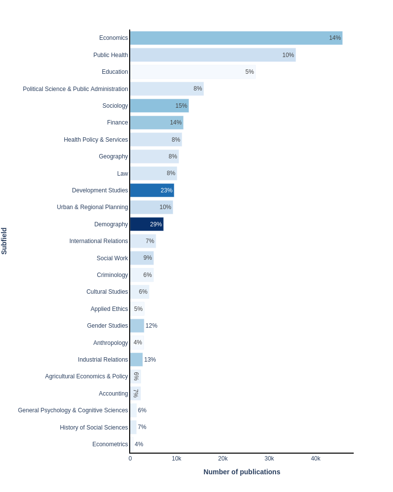

Figure 1. Top 25 subfields with the largest percentage of Scopus publication included in the publication set.

## Journals

In this section, we show how the publication set, captured by the query above, relates to scholarly journals. Journals are sorted in terms of their relevance using term frequency-inverse document frequency (TF-IDF). The horizontal bars are proportional to the number of publications contributed by the journal to the current publication set. The number alongside the horizontal bar is the proportion of the journal contributing to this publication set.

The articles on this topic are published most frequently in the following journals: *PLoS ONE* (2,965 publications), *Social Science and Medicine* (2,371), and *International Journal of Environmental Research and Public Health* (2,216).

Note, larger journals may not appear in the table below, as their SDG contribution may be relatively small compared to the size of the journal.

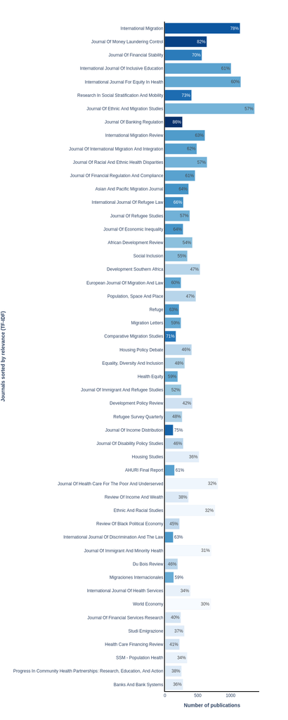

Figure 2. Top 50 journals, in terms of relevance (TF-IDF), for this publication set.

## Keywords

Elsevier’s [Scopus](https://www.scopus.com/search/form.uri?display=basic#basic) database of scientific literature, was used for the table below. The document types included in the data sets are journal articles, reviews, short surveys and conference papers, covering the period 1996–2022. We refer to these documents collectively as “publications” or “papers”.

In order to help better illustrate the content of this set of publications, indicators associated with the keywords most specific to this set (according to a TF-IDF score) are presented below.

|  | Term | # of papers with this term in the publication set | # of papers with this term in all of Scopus | Relevance (TF-IDF) | Percentage of Scopus |
| --- | --- | --- | --- | --- | --- |
| 1 | racial/ethnic disparities | 2185 | 2363 | 18.7662 | 92 |
| 2 | health care disparities | 1683 | 1814 | 18.7612 | 93 |
| 3 | centers for medicare and medicaid services | 2848 | 3141 | 18.7133 | 91 |
| 4 | socioeconomic disparities | 2032 | 2266 | 18.7083 | 90 |
| 5 | centers for medicare and medicaid | 3026 | 3343 | 18.7026 | 91 |
| 6 | socioeconomic inequalities | 2567 | 2867 | 18.6986 | 90 |
| 7 | racial disparity | 1918 | 2153 | 18.6946 | 89 |
| 8 | health disparity | 1598 | 1791 | 18.6846 | 89 |
| 9 | racial and ethnic disparities | 1676 | 1903 | 18.6653 | 88 |
| 10 | healthcare disparities | 1623 | 1842 | 18.6632 | 88 |

[output cut: 990 more lines]